# Final Project

Hunter Schuller

4/29/2022

### Introduction

```r
library(ggplot2)
library(tidyverse)
library(gapminder)
library(countrycode)
library(purrr)
library(ggrepel)
athlete_events <- read_csv(file = 'athlete_events.csv',
   col_types = cols(ID = 'i', Age = 'i', Height = 'i', Year = 'i'))
noc_regions <- read_csv('noc_regions.csv')
noc_regions$NOC <- noc_regions$NOC %>% countrycode(origin = "ioc", destination = "iso3c")
noc_regions$Index <- 1:230
noc_regions <- noc_regions %>%
  filter(!is.na(NOC))
socio_eco_one <- gapminder_unfiltered
socio_eco_five <- gapminder
host_cities <- read_csv("host_cities.csv")
```

I have loaded in the standard `ggplot` and `tidyverse` for data manipulation and graphing. The libraries `gapminder` and `countrycode` are used for data purposes. I imported the CVSs `athlete_events` and `noc_regions` whilst cleaning up the columns and country code formatting. I renamed the two data frames we use from `gapminder` with more readable names. Finally, I imported the `host_cities` data set.

### Question 1

## Is there a relationship between GDP and number of medals?

```r
socio_eco_one <- socio_eco_one %>%
  filter(year %in% c(seq(1952,2004, by=4))) %>%
  left_join(noc_regions, by = c("country" = "region"))
getGDP <- function(x, y){
  vec <- filter(socio_eco_one, NOC == x, year == y)
  return(vec$gdpPercap)
}


gdpMedals <- athlete_events %>%
  group_by(NOC, Year) %>%
  summarise(Medals = sum(!is.na(Medal))) %>%
  filter(Year > 1951)
```

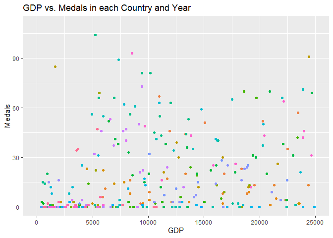

```r
gdpMedals$GDP <- rep(0, 2896)
for(i in 1:nrow(gdpMedals)) {
  x <- getGDP(gdpMedals$NOC[i], gdpMedals$Year[i])
  if(length(x) == 0){
    gdpMedals$GDP[i] <- -1
  }else{
    gdpMedals$GDP[i] <- x
  }
}
gdpMedals <- gdpMedals %>%
  filter(GDP > 0) %>%
  mutate(GDPLevel = ifelse(GDP < 10000, "Lower", ifelse(GDP < 20000, "Middle", "Higher")),
         MedalsLevel = ifelse(Medals < 15, "Lower", ifelse(Medals < 35, "Middle", "Higher")))


ggplot(gdpMedals) +
  geom_point(aes(x = GDP, y = Medals, color = NOC)) +
  theme(legend.position = "none") +
  xlim(0, 25000) +
  ylim(0, 110) +
  ggtitle("GDP vs. Medals in each Country and Year")
```

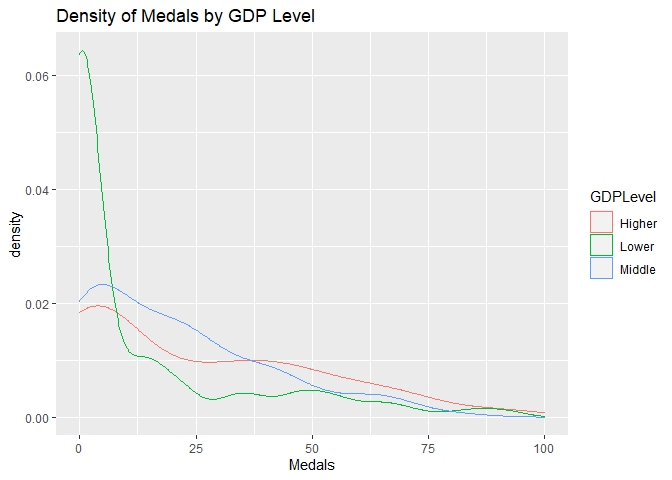

```r
ggplot(gdpMedals) +
  geom_density(aes(x = Medals, color = GDPLevel)) +
  xlim(0, 100) +
  ggtitle("Density of Medals by GDP Level")
```

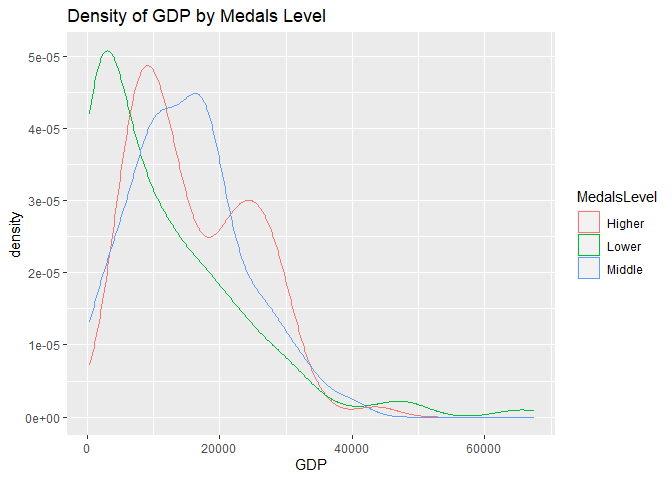

```r
ggplot(gdpMedals) +
  geom_density(aes(x = GDP, color = MedalsLevel)) +
  ggtitle("Density of GDP by Medals Level")
```

For the code portion of this question, there was much to be used from the modules. The first step was to `left_join` the `socio_eco_one` with `noc_regions` to have the NOC with the country’s GDP for each year. This process was covered in Module 7 about joins and combining data frames. Next, I used dplyr functions covered in Module 4 to summarize the number of medals from each year and NOC. I added the factor variables for GDP and Medals as Lower, Middle, and Higher. With the data all set, I plotted GDP versus Medals, and then the density of Medals by GDP level and GDP by Medal Levels.  
The scatter plot shows GDP versus Medals for all of the available data points. We can makes some conclusions from this graph. First, just because a country has a high GDP, doesn’t mean they are guaranteed a medal. Second, the countries with lots of medals tend to be in the middle of the pack in terms of GDP. Lastly, most low GDP countries don’t earn any medals.  
For the density plots, it confirms our analysis that low GDP countries don’t get any medals. Also, we can say countries who get tons of medals are almost equally distributed as the medal counts reach 75 or more. The next plot confirms that there is a large density of the Higher Medal factor in the median range of GDP.  
As for the question, we can see that there is some relationship between GDP and medals earned at the Olympics. Low GDP countries tend to not earn any medals. Middle and High GDP countries tend to be distributed between no medals and the highest amount.

### Question 2

## Is there a host country effect on the number of medals? In other words, do countries earn more medals when they host an Olympic games?

```r
getNOC <- function(country){
  row <- filter(noc_regions, region == country)
  return(ifelse(length(row$NOC) == 0, "NULL", row$NOC))
}
hostCity <- athlete_events %>%
  left_join(host_cities, by = c("City" = "city")) %>%
  mutate(hostNOC = "NULL") %>%
  select(country, hostNOC, Medal, NOC) %>%
  group_by(country, hostNOC, NOC) %>%
  summarize(Medals = sum(!is.na(Medal)))
```

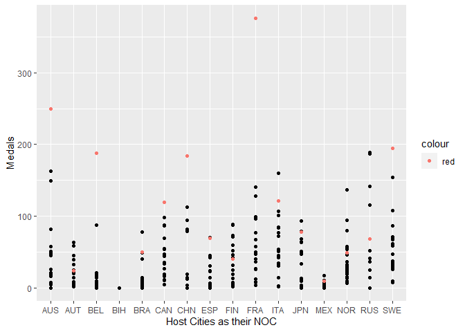

```r
for(i in 1:nrow(hostCity)){
  hostCity$hostNOC[i] <- getNOC(hostCity$country[i])
}
hostNOCList <- unique(hostCity$hostNOC)
hostCity <- hostCity %>%
  filter(hostNOC != "NULL", NOC %in% hostNOCList)
hostCityMedals <- subset(hostCity, NOC == hostNOC)

ggplot() +
  geom_point(data = hostCity, aes(x = as.factor(NOC), y = Medals)) +
  geom_point(data = hostCityMedals, aes(x = as.factor(NOC), y = Medals, color = "red")) +
  xlab("Host Cities as their NOC")
```

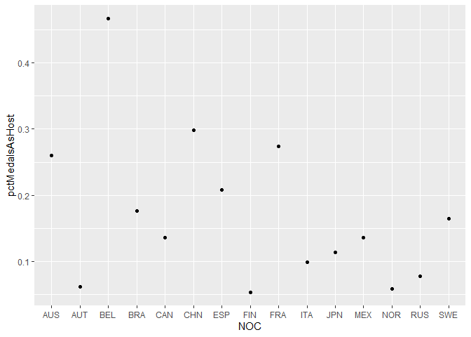

```r
hostCity %>%
  group_by(NOC) %>%
  summarise(totalMedals = sum(Medals)) %>%
  right_join(hostCityMedals, by = c("NOC" = "NOC")) %>%
  summarise(pctMedalsAsHost = Medals/totalMedals, NOC) %>%
  ggplot() +
  geom_point(aes(x = NOC, y = pctMedalsAsHost))
```

### Question 3

## Is there a relationship between age and number of gold, silver, and bronze medals?

```r
age <- athlete_events %>%
  select(Age, Medal) %>%
  filter(!is.na(Age) & !is.na(Medal))%>%
  group_by(Medal, Age) %>%
  summarise(numMedals = n())
```

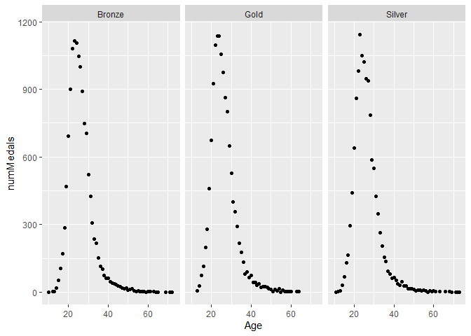

```r
ggplot(data = age) +
  geom_point(aes(x = Age, y = numMedals)) +
  facet_wrap(vars(Medal))
```

The code uses dplyr verbs, ggplot, and faceting. I filtered and grouped the `athlete_events` data set for each medal type and age. With this filter, I can create a scatter plot that is faceted for each type of medal.  
Although the graphs look fairly similar, there are significant differences. The oldest gold medal winner is barely over 60, while the oldest bronze and silver medal winners are over 70. The peak of gold medals is slightly thinner than other medals, meaning there is a smaller range to earn gold medals.  
To answer the question, there is a relationship between age and number of gold, silver, and bronze medals. The peak age of earning medals is between 20 and 30. As people get older, their chances of earning a medal significantly decreases. As people get over 60 years old, their chances of getting a gold medal decrease, while it is still viable to get a silver or bronze medal.